# random forest

Jacob Buffa

March 24, 2020

## MODEL OBJECTIVE

kmeans, bagged CART, and CART models have all been tried so far. CART has gotten the closest. The decision tree created had the logic that was fairly accurate. This next model will be created with the goal of seeing if added complexity helps the model.

A Random Forest Model was chosen to increase complexity with a different tuning parameter without losing interpretibility.

### Load Libraries & Data

```r
library(caret)
library(randomForest)
library(tidyverse)
library(igraph)
library(ggraph)

# Scoring Function
custom.scoring <- function(x){
  scale(x)*10+50
}

# tree graphing function
tree_func <- function(final_model, tree_num) {

  # get tree by index
  tree <- randomForest::getTree(final_model,
                                k = tree_num,
                                labelVar = TRUE) %>%
    tibble::rownames_to_column() %>%
    # make leaf split points to NA, so the 0s won't get plotted
    mutate(`split point` = ifelse(is.na(prediction), `split point`, NA))

  # prepare data frame for graph
  graph_frame <- data.frame(from = rep(tree$rowname, 2),
                            to = c(tree$`left daughter`, tree$`right daughter`))

  # convert to graph and delete the last node that we don't want to plot
  graph <- graph_from_data_frame(graph_frame) %>%
    delete_vertices("0")

  # set node labels
  V(graph)$node_label <- gsub("_", " ", as.character(tree$`split var`))
  V(graph)$leaf_label <- as.character(tree$prediction)
  V(graph)$split <- as.character(round(tree$`split point`, digits = 2))

  # plot
  plot <- ggraph(graph, 'dendrogram') +
    theme_bw() +
    geom_edge_link() +
    geom_node_point() +
    geom_node_text(aes(label = node_label), na.rm = TRUE, repel = TRUE) +
    geom_node_label(aes(label = split), vjust = 2.5, na.rm = TRUE, fill = "white") +
    geom_node_label(aes(label = leaf_label, fill = leaf_label), na.rm = TRUE,
                    repel = TRUE, colour = "white", fontface = "bold", show.legend = FALSE) +
    theme(panel.grid.minor = element_blank(),
          panel.grid.major = element_blank(),
          panel.background = element_blank(),
          plot.background = element_rect(fill = "white"),
          panel.border = element_blank(),
          axis.line = element_blank(),
          axis.text.x = element_blank(),
          axis.text.y = element_blank(),
          axis.ticks = element_blank(),
          axis.title.x = element_blank(),
          axis.title.y = element_blank(),
          plot.title = element_text(size = 18))

  print(plot)
}

powerAthletes <- c('Cody Klotz','Isaiah Williams','Cruz Valencia','Cade Mahn','Derek Stanley','Drake Lubin','Jordan Johnson','Kyle Fowler','Matthew Nolan',
'Clayton Giorgio','Mycole Pruitt','Tyler Reichenborn','Zach Bryce','Ryan Hoshaw','Markel Smith','Max Datoli','Robert Ford 3','Wyatt Brockman','Robby Manor')

athleticAthletes <- c('Alex Hoff','Ben Borgann','Ben Smith','Braden Barnard','Jacob Buffa','Brett Fischer','Andrew Buescher','Anthony Green','Arturo Romero','Braxton Martinez',
'Bryce Horstman','Cade Schares','Cameron Haegele','Cody Creed','Darian Crisp','Dennis Jordan','DJ Miller','Evan Martin','Jehu','Josh Bunselmeyer','Matt Rehder',
'Taylor Robinson','Tony Adams','Zeb Roos','Dexter Swims','Eric Loomis','Ian Lohse','Nathaniel Sems')

momentumAthletes <- c('Alex Henagean','Andrew Ness','Braden Burcham','Blaise Matheny','Brady Cook','Bryce Grossius','Charlie Bourneuf','Cody Siebenberger','Elias Stevens',
'Matthew Kaiser','Hunter Counton','Jake Matheny','Keaton Greiwe','Landon Johnson','Matthew Arnold','Nathan Beaton','Nicholas Harms','Paul Noel','Ryan Malzahn',
'Ryan Miller', 'Tate Matheny', 'Tommy Shriver','Troy Schneider','Tyson James','Zach Brasier','Zach Voss','Carson Maloney','Isaac Parks')

trainingAthletes <- c('Aaron Schromm','Adam Lackey','Adam Rakowiecki','Aidan McNamee','Alex Gladson','Anthony Altobella','Andrew Hartle','Avery Himes','Ben Axelrod',
'Ben Kennebeck','Ben Sems','Brady Heinzmann','Brandon Murphy','Brayden Arnold','Brandon Odehnal','Cannon Hritz','Cherokee Boynton','Cole Bornhop','Craig Mcgee',
'Daniel Covert','Denton McNamee','DeAngelo Sommers','Derek Archer','Drake Kanallakan','Dylan Mooney','Erik Keiweit','Erich Dodge','Evan Clawson','Evan Fufaro',
'Gavin Oswald','Gavyn Dockery','Ian Funk','Greg Hamilton','Grant Middendorf','Grant Miller','Jack Hunke','Jackson Hogan','James Bradley','James Murray','Jonathon Bonner',
'Josh Falke','JT Mabry','Louis Niemerg','Michael Long','Mike Fuller','Mitchell Davis','Nick Alberico','Nick Heine','Noah Reichman','Patrick Deemer','Tanner Marshall',
'Tommy Woods','Tripp Johns','Ty Stauss','Xavier Flores','Zane Roos')

# Tables
athleteInfo <- read.csv("AthleteInformation1.csv")
allData <- read.csv("FINAL TABLE.csv")
```

### Data Processing

```r
# ORGANIZE
athleteInfo <-
  athleteInfo %>%
  transform(Birthday = as.Date(Birthday, format = "%m/%d/%Y")) %>%
  mutate(Gender = ifelse(Gender == "F", "F","M"))

masterData <-
  allData %>%
  mutate(Avg..Relative.Braking.Force = (Avg..Braking.Force/System.Weight)*100,
         Avg..Relative.Braking.Power = Avg..Braking.Power/System.Weight,
         Avg..Relative.Propulsive.Power = Avg..Propulsive.Power/System.Weight) %>%
  mutate(Avg..Braking.Velocity = abs(Avg..Braking.Velocity), # change negative numbers to positive
         Avg..Braking.Power = abs(Avg..Braking.Power),
         Avg..Relative.Braking.Power = abs(Avg..Relative.Braking.Power)) %>%
  transform(Date = as.Date(Date, format = "%m/%d/%Y"),
            Name = as.character(Name)) %>%
  left_join(athleteInfo, by = "Name") %>%
  filter(Gender == "M")

variables <- colnames(masterData)
brakingMetrics <- variables[c(5:7,12,13,16,17,19)]
propulsiveMetrics <- variables[c(9:11,14,15,47,53:55)]
balanceMetrics <- variables[c(25:34)]

# CENTER AND SCALE
clusterData <- masterData %>%
  mutate_at(vars(brakingMetrics,propulsiveMetrics), custom.scoring) %>%
  group_by(Name) %>%
  summarise_at(vars(brakingMetrics, propulsiveMetrics), mean, na.rm = TRUE)
clusterData <- na.omit(clusterData) # remove NA

# IDENTIFY CORRELATED PREDICTORS
cormatrix <- cor(clusterData[,-1])
summary(cormatrix[upper.tri(cormatrix)])
```

```
##    Min. 1st Qu.  Median    Mean 3rd Qu.    Max.
## -0.7387  0.1973  0.5113  0.4096  0.7020  0.9685
```

```r
#highlyCor <- findCorrelation(cormatrix, cutoff = .8)
#filterclusterData <- clusterData[,-highlyCor]
```

Data has been cleaned, centered, and scaled for the model. Normally would elimate linear dependencies, but Performance Driver metrics have been selected based on domain expertise.

```r
labels <-
  clusterData %>%
  mutate(Class = case_when(Takeoff.Velocity > Avg..Propulsive.Velocity+2 &
                             Avg..Propulsive.Force > Avg..Propulsive.Velocity+2 ~ 'Momentum',
                           Takeoff.Velocity <= Avg..Propulsive.Velocity+2 &
                             Avg..Propulsive.Force <= Avg..Propulsive.Velocity+2 &
                             Avg..Braking.Force < Avg..Braking.Velocity-2 ~ 'Power',
                           Takeoff.Velocity <= Avg..Propulsive.Velocity+2 &
                             Avg..Propulsive.Force <= Avg..Propulsive.Velocity+2 &
                             Avg..Braking.Force >= Avg..Braking.Velocity-2 ~ 'Athletic')) %>%
  select(Name, Class)

treeData <-
  masterData %>%
  mutate_at(vars(brakingMetrics,propulsiveMetrics), custom.scoring) %>%
  group_by(Name, Date) %>%
  summarise_at(vars(brakingMetrics, propulsiveMetrics), mean, na.rm = TRUE) %>%
  left_join(labels, by = 'Name') %>%
  ungroup() %>%
  mutate(Class = ifelse(is.na(Class), 'Unknown',Class)) %>%
  group_by(Name) %>%
  mutate(Per = n()/1118) %>%
  mutate(Outlier = ifelse(Per > .02 & Avg..Propulsive.Force <= quantile(Avg..Propulsive.Force, .6, na.rm = TRUE),1,0)) %>%
  filter(Outlier == 0) %>%
  select(Name, Avg..Braking.Force, Avg..Braking.Velocity, Avg..Relative.Braking.Force, Avg..Propulsive.Force,
         Avg..Relative.Propulsive.Force, Avg..Propulsive.Velocity,Avg..Propulsive.Force, Takeoff.Velocity,
         Class) %>% na.omit()
```

Condense data to assign labels to the athletes that I am confident in, and fit the logic derived from Performance Driver metrics. Then expand data back to have more data points to train the model. Identify Athletes that have enough tests to bias the sample, and only keep the top 40% of their tests. Finally, remove and NA values. I want to leave out the Velocity difference variable in the first model just to see what variable importance the model selects first.

### Data Splitting

```r
train.tree <- treeData[,-1] %>% filter(Class != 'Unknown')
test.tree <- treeData[,-1] %>% filter(Class == 'Unknown')
```

Ideally these would be random splits. But for the purposes of this model, I have split the training set and testing set based on athletes with and without pre-assigned labels

### Model Training & Tuning

```r
# Resampling method of repeated cross validation
fitControl <- trainControl(
  method = "repeatedcv",
  number = 10,
  repeats = 10
)

# Model Training
tuneGrid <- expand.grid(.mtry = (1:9))
set.seed(234)
rf.model <- train(Class ~., data = train.tree,
                    method = 'rf',
                    tuneGrid = tuneGrid,
                    trControl = fitControl)

rf.model
```

```
## Random Forest
##
## 592 samples
##   7 predictor
##   3 classes: 'Athletic', 'Momentum', 'Power'
##
## No pre-processing
## Resampling: Cross-Validated (10 fold, repeated 10 times)
## Summary of sample sizes: 533, 533, 533, 532, 532, 533, ...
## Resampling results across tuning parameters:
##
##   mtry  Accuracy   Kappa
##   1     0.8080685  0.6907621
##   2     0.8133280  0.7003171
##   3     0.8158421  0.7048494
##   4     0.8156726  0.7043725
##   5     0.8166756  0.7062130
##   6     0.8156902  0.7044941
##   7     0.8172213  0.7071859
##   8     0.8166760  0.7065740
##   9     0.8155006  0.7042698
##
## Accuracy was used to select the optimal model using the largest value.
## The final value used for the model was mtry = 7.
```

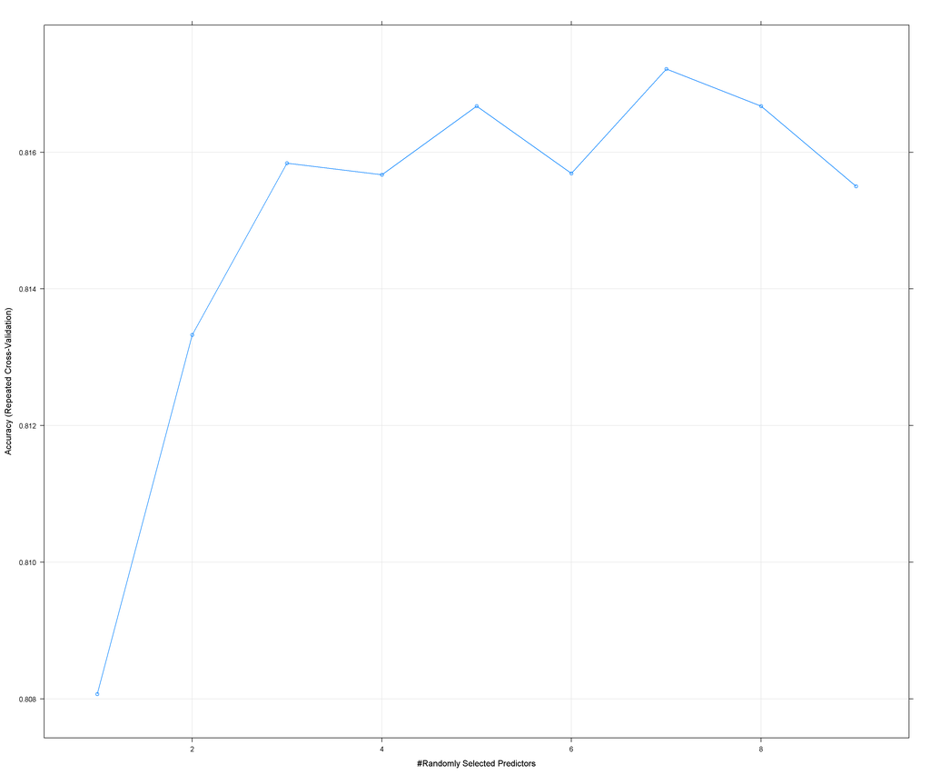

```r
plot(rf.model)
```

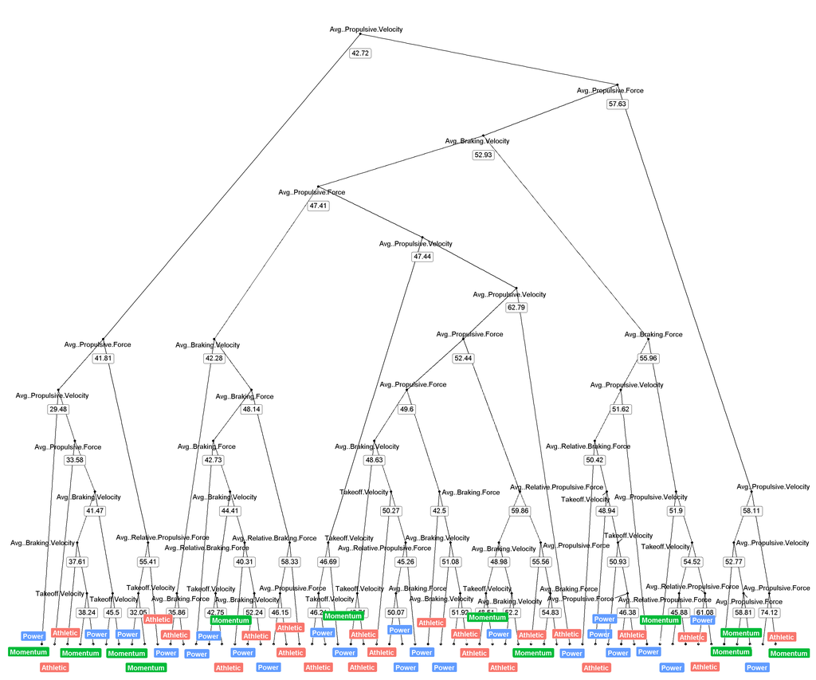

```r
# min number of trees
tree_num <- which(rf.model$finalModel$forest$ndbigtree == min(rf.model$finalModel$forest$ndbigtree))
tree_func(rf.model$finalModel, tree_num)
```

### Predicting Outcomes

```r
# get predicted labels
rf.pred <- predict.train(rf.model, newdata = test.tree)

# Distribution of predicted labels
sum(rf.pred == 'Athletic')
```

```
## [1] 117
```

```r
sum(rf.pred == 'Power')
```

```
## [1] 164
```

```r
sum(rf.pred == 'Momentum')
```

```
## [1] 203
```

```r
# assign labels to athletes and view results
treeData %>%
  filter(Class == 'Unknown') %>%
  select(Name)%>%
  add_column(pred.class = rf.pred) %>% view()
```

### Conclusion

*By far the best model so far. Highest accuracy score, and liked the athlete predictions a lot. There were a few misclassifications on athletes that I felt were obvious. It makes me question if the original logic I defined is 100% correct. I could assign more labels to athletes to help improve the training set. Either way, I think I have found the model type that is the sweet spot between complexity and interpretibility for this problem. Next step is to add in the propulsive velo difference variable*

### Model 2 Training & Tuning

```r
# add velo difference as a variables
treeData.2 <-
  masterData %>%
  mutate_at(vars(brakingMetrics,propulsiveMetrics), custom.scoring) %>%
  group_by(Name, Date) %>%
  summarise_at(vars(brakingMetrics, propulsiveMetrics), mean, na.rm = TRUE) %>%
  left_join(labels, by = 'Name') %>%
  ungroup() %>%
  mutate(Class = ifelse(is.na(Class), 'Unknown',Class)) %>%
  group_by(Name) %>%
  mutate(Per = n()/1118) %>%
  mutate(Outlier = ifelse(Per > .02 & Avg..Propulsive.Force <= quantile(Avg..Propulsive.Force, .6, na.rm = TRUE),1,0)) %>%
  filter(Outlier == 0) %>%
  mutate(Propulsive.Velo.Diff = Avg..Propulsive.Velocity - Takeoff.Velocity) %>%
  select(Name, Avg..Braking.Force, Avg..Braking.Velocity, Avg..Relative.Braking.Force, Avg..Propulsive.Force,
         Avg..Relative.Propulsive.Force, Avg..Propulsive.Velocity, Takeoff.Velocity,
         Propulsive.Velo.Diff,Class) %>% na.omit()

train.tree.2 <- treeData.2[,-1] %>% filter(Class != 'Unknown')
test.tree.2 <- treeData.2[,-1] %>% filter(Class == 'Unknown')

# Resampling method of repeated cross validation
fitControl <- trainControl(
  method = "repeatedcv",
  number = 10,
  repeats = 10
)

# Model Training
tuneGrid <- expand.grid(.mtry = (1:9))
set.seed(234)
rf.model.2 <- train(Class ~., data = train.tree.2,
                    method = 'rf',
                    tuneGrid = tuneGrid,
                    trControl = fitControl)

rf.model.2
```

```
## Random Forest
##
## 592 samples
##   8 predictor
##   3 classes: 'Athletic', 'Momentum', 'Power'
##
## No pre-processing
## Resampling: Cross-Validated (10 fold, repeated 10 times)
## Summary of sample sizes: 533, 533, 533, 532, 532, 533, ...
## Resampling results across tuning parameters:
##
##   mtry  Accuracy   Kappa
##   1     0.8207009  0.7114689
##   2     0.8262856  0.7218308
##   3     0.8333877  0.7335836
##   4     0.8323562  0.7321392
##   5     0.8261161  0.7223355
##   6     0.8244356  0.7196108
##   7     0.8198792  0.7125134
##   8     0.8200715  0.7126215
##   9     0.8185401  0.7102856
##
## Accuracy was used to select the optimal model using the largest value.
## The final value used for the model was mtry = 3.
```

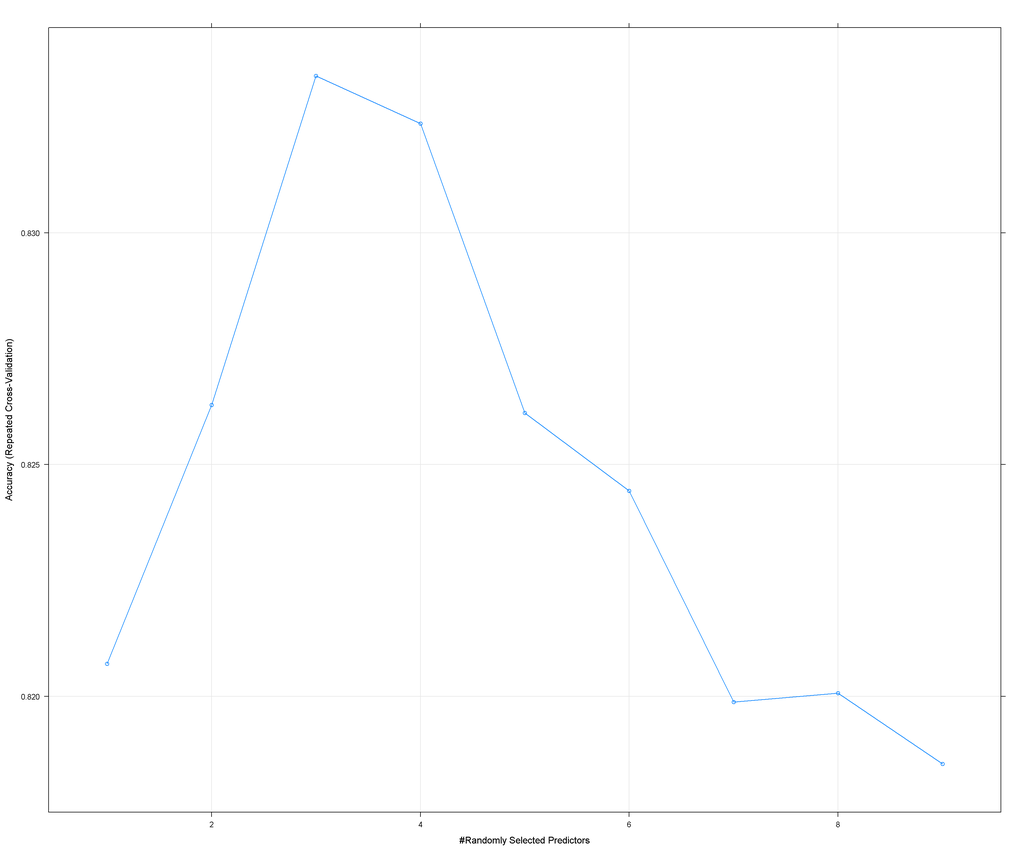

```r
plot(rf.model.2)
```

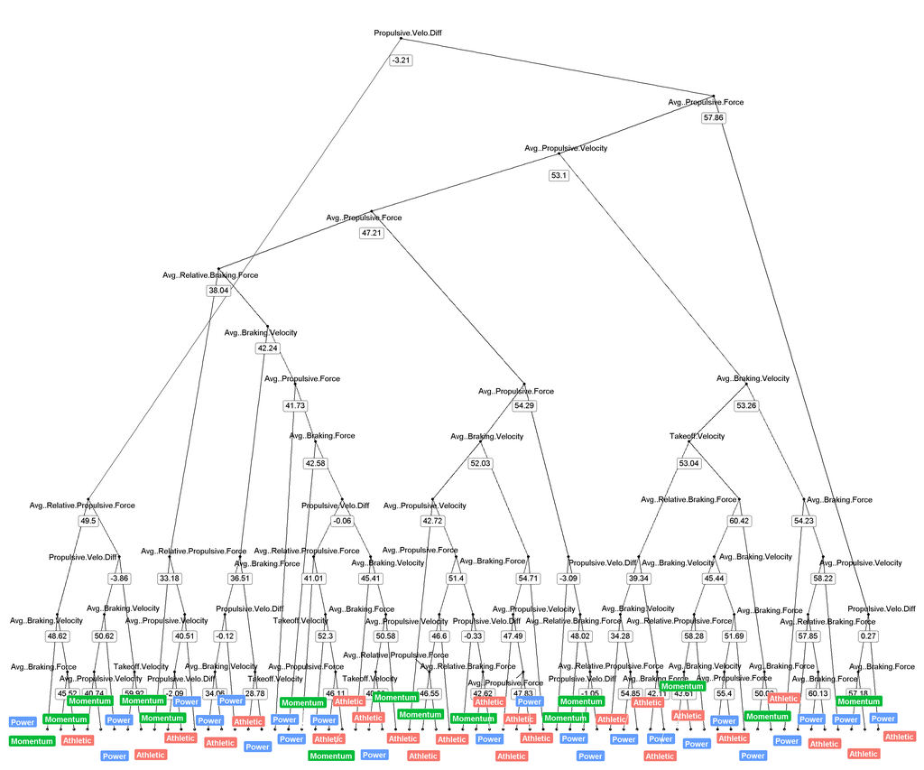

```r
# min number of trees
tree_num <- which(rf.model.2$finalModel$forest$ndbigtree == min(rf.model.2$finalModel$forest$ndbigtree))
tree_func(rf.model.2$finalModel, tree_num)
```

### Predicting Outcomes of Model 2

```r
# get predicted labels
rf.pred.2 <- predict.train(rf.model.2, newdata = test.tree.2)

# Distribution of predicted labels
sum(rf.pred.2 == 'Athletic')
```

```
## [1] 188
```

```r
sum(rf.pred.2 == 'Power')
```

```
## [1] 156
```

```r
sum(rf.pred.2 == 'Momentum')
```

```
## [1] 140
```

```r
# assign labels to athletes and view results
treeData %>%
  filter(Class == 'Unknown') %>%
  select(Name)%>%
  add_column(pred.class = rf.pred.2) %>% view()
```

### Conclusion

*Slightly more accurate than the first model. Which would make this the most accurate so far. After reviewing the predicted labels, and my original labels, I am beggining to think the original logic laid out to classify athletes is flawed. I am going to try another method of labeling. I am going to label and train the model on only high level athletes that I am confident in. I think younger, undeveloped athletes are difficult to label. We will see if this changes anything in the next model.*

### Model 3 Training & Tuning

```r
treeData.3 <-
  masterData %>%
  mutate_at(vars(propulsiveMetrics), custom.scoring) %>%
  group_by(Name, Date) %>%
  summarise_at(vars(propulsiveMetrics), mean, na.rm = TRUE) %>%
  ungroup() %>%
  mutate(Class = case_when(Name %in% momentumAthletes ~ 'Momentum',
                           Name %in% athleticAthletes ~ 'Athletic',
                           Name %in% powerAthletes ~ 'Power',
                           Name %in% trainingAthletes ~ 'Training',
                           !Name %in% c(momentumAthletes,athleticAthletes,powerAthletes,trainingAthletes) ~ 'Unknown')) %>%
  mutate(Accel.TakeoffVelo.Diff = Avg..Relative.Propulsive.Force - Takeoff.Velocity,
         Velo.Diff = Avg..Propulsive.Velocity - Takeoff.Velocity) %>%
  group_by(Name) %>%
  mutate(Per = n()/1118) %>%
  mutate(Outlier = ifelse(Per > .02 & Avg..Propulsive.Force <= quantile(Avg..Propulsive.Force, .6, na.rm = TRUE),1,0)) %>%
  filter(Outlier == 0) %>%
  #mutate(Propulsive.Velo.Diff = Avg..Propulsive.Velocity - Takeoff.Velocity) %>%
  select(Name,Avg..Relative.Propulsive.Force, Avg..Propulsive.Velocity, Takeoff.Velocity, Accel.TakeoffVelo.Diff,
         Velo.Diff, Class) %>% na.omit()

train.tree.3 <- treeData.3[,-1] %>% filter(Class %in% c('Momentum','Athletic','Power'))
test.tree.3 <- treeData.3[,-1] %>% filter(Class == 'Training')

# Resampling method of repeated cross validation
fitControl <- trainControl(
  method = "repeatedcv",
  number = 10,
  repeats = 10
)

# Model Training
tuneGrid <- expand.grid(.mtry = (0:9))
set.seed(234)
rf.model.3 <- train(Class ~., data = train.tree.3,
                    method = 'rf',
                    tuneGrid = tuneGrid,
                    trControl = fitControl)

rf.model.3
```

```
## Random Forest
##
## 307 samples
##   5 predictor
##   3 classes: 'Athletic', 'Momentum', 'Power'
##
## No pre-processing
## Resampling: Cross-Validated (10 fold, repeated 10 times)
## Summary of sample sizes: 277, 276, 275, 276, 276, 277, ...
## Resampling results across tuning parameters:
##
##   mtry  Accuracy   Kappa
##   0     0.8133105  0.6975797
##   1     0.8149247  0.6999776
##   2     0.8080605  0.6903725
##   3     0.8021794  0.6810872
##   4     0.7982534  0.6750963
##   5     0.7976297  0.6741303
##   6     0.7944227  0.6691640
##   7     0.7963172  0.6718761
##   8     0.7979738  0.6744213
##   9     0.7943710  0.6689763
##
## Accuracy was used to select the optimal model using the largest value.
## The final value used for the model was mtry = 1.
```

```r
rf.model.3$finalModel
```

```
##
## Call:
##  randomForest(x = x, y = y, mtry = param$mtry)
##                Type of random forest: classification
##                      Number of trees: 500
## No. of variables tried at each split: 1
##
##         OOB estimate of  error rate: 19.87%
## Confusion matrix:
##          Athletic Momentum Power class.error
## Athletic       87       23    10  0.27500000
## Momentum       12      122     0  0.08955224
## Power          16        0    37  0.30188679
```

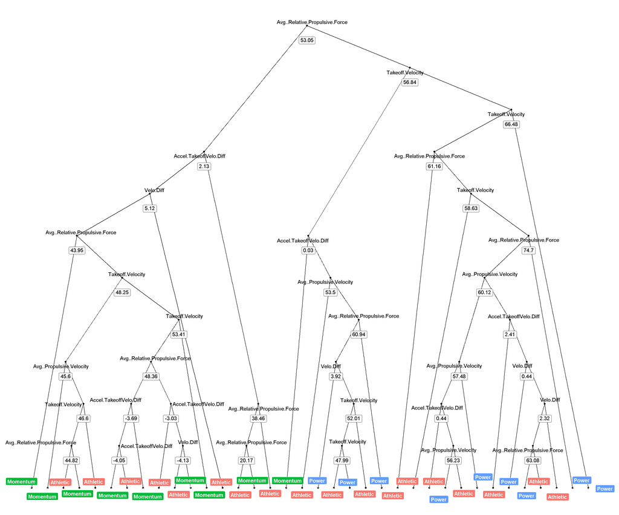

```r
# min number of trees
tree_num <- which(rf.model.3$finalModel$forest$ndbigtree == min(rf.model.3$finalModel$forest$ndbigtree))
tree_func(rf.model.3$finalModel, tree_num)
```

### Predicting Outcomes of Model 3

```r
# get predicted labels
rf.pred.3 <- predict.train(rf.model.3, newdata = test.tree.3)

# Distribution of predicted labels
sum(rf.pred.3 == 'Athletic')
```

```
## [1] 64
```

```r
sum(rf.pred.3 == 'Power')
```

```
## [1] 22
```

```r
sum(rf.pred.3 == 'Momentum')
```

```
## [1] 177
```

```r
# assign labels to athletes and view results
treeData.3 %>%
  filter(Class == 'Training') %>%
  select(Name)%>%
  add_column(pred.class = rf.pred.3) %>% view()
```

### Save Model

```r
random_forest_model <- rf.model.3$finalModel
saveRDS(random_forest_model, './random_forest_model.rds')
```